# final_titanic

```python
import pandas as pd
df=pd.read_csv(r"c:\users\user\Documents\titanic\titanic.csv")
df.head()
```

|  | Survived | Pclass | Name | Sex | Age | Siblings/Spouses Aboard | Parents/Children Aboard | Fare |
| --- | --- | --- | --- | --- | --- | --- | --- | --- |
| 0 | 0 | 3 | Mr. Owen Harris Braund | male | 22.0 | 1 | 0 | 7.2500 |
| 1 | 1 | 1 | Mrs. John Bradley (Florence Briggs Thayer) Cum... | female | 38.0 | 1 | 0 | 71.2833 |
| 2 | 1 | 3 | Miss. Laina Heikkinen | female | 26.0 | 0 | 0 | 7.9250 |
| 3 | 1 | 1 | Mrs. Jacques Heath (Lily May Peel) Futrelle | female | 35.0 | 1 | 0 | 53.1000 |
| 4 | 0 | 3 | Mr. William Henry Allen | male | 35.0 | 0 | 0 | 8.0500 |

```python
df.tail()
```

|  | Survived | Pclass | Name | Sex | Age | Siblings/Spouses Aboard | Parents/Children Aboard | Fare |
| --- | --- | --- | --- | --- | --- | --- | --- | --- |
| 882 | 0 | 2 | Rev. Juozas Montvila | male | 27.0 | 0 | 0 | 13.00 |
| 883 | 1 | 1 | Miss. Margaret Edith Graham | female | 19.0 | 0 | 0 | 30.00 |
| 884 | 0 | 3 | Miss. Catherine Helen Johnston | female | 7.0 | 1 | 2 | 23.45 |
| 885 | 1 | 1 | Mr. Karl Howell Behr | male | 26.0 | 0 | 0 | 30.00 |
| 886 | 0 | 3 | Mr. Patrick Dooley | male | 32.0 | 0 | 0 | 7.75 |

```python
df.shape
```

```
(887, 8)
```

```python
df.info()
```

```
<class 'pandas.core.frame.DataFrame'>
RangeIndex: 887 entries, 0 to 886
Data columns (total 8 columns):
 #   Column                   Non-Null Count  Dtype
---  ------                   --------------  -----
 0   Survived                 887 non-null    int64
 1   Pclass                   887 non-null    int64
 2   Name                     887 non-null    object
 3   Sex                      887 non-null    object
 4   Age                      887 non-null    float64
 5   Siblings/Spouses Aboard  887 non-null    int64
 6   Parents/Children Aboard  887 non-null    int64
 7   Fare                     887 non-null    float64
dtypes: float64(2), int64(4), object(2)
memory usage: 55.6+ KB
```

```python
df.duplicated().sum
```

[output not shown]

```python
df.dtypes
```

```
Survived                     int64
Pclass                       int64
Name                        object
Sex                         object
Age                        float64
Siblings/Spouses Aboard      int64
Parents/Children Aboard      int64
Fare                       float64
dtype: object
```

```python
import seaborn as sns
import matplotlib.pyplot as plt
```

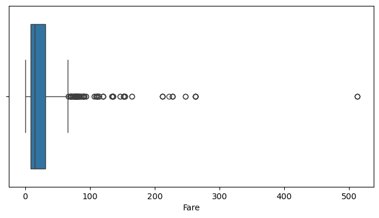

```python
plt.figure(figsize=(8,4))
sns.boxplot(data=df,x=df["Fare"])
plt.show()
```

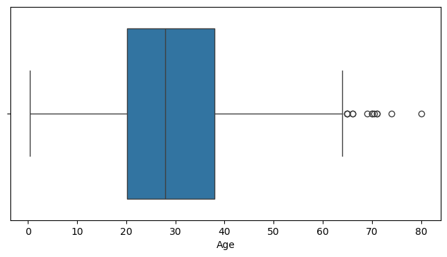

```python
plt.figure(figsize=(8,4))
sns.boxplot(data=df,x=df["Age"])
plt.show()
```

```python
df.describe()
```

|  | Survived | Pclass | Age | Siblings/Spouses Aboard | Parents/Children Aboard | Fare |
| --- | --- | --- | --- | --- | --- | --- |
| count | 887.000000 | 887.000000 | 887.000000 | 887.000000 | 887.000000 | 887.00000 |
| mean | 0.385569 | 2.305524 | 29.471443 | 0.525366 | 0.383315 | 32.30542 |
| std | 0.487004 | 0.836662 | 14.121908 | 1.104669 | 0.807466 | 49.78204 |
| min | 0.000000 | 1.000000 | 0.420000 | 0.000000 | 0.000000 | 0.00000 |
| 25% | 0.000000 | 2.000000 | 20.250000 | 0.000000 | 0.000000 | 7.92500 |
| 50% | 0.000000 | 3.000000 | 28.000000 | 0.000000 | 0.000000 | 14.45420 |
| 75% | 1.000000 | 3.000000 | 38.000000 | 1.000000 | 0.000000 | 31.13750 |
| max | 1.000000 | 3.000000 | 80.000000 | 8.000000 | 6.000000 | 512.32920 |

```python
df["Survived"].value_counts()
```

```
Survived
0    545
1    342
Name: count, dtype: int64
```

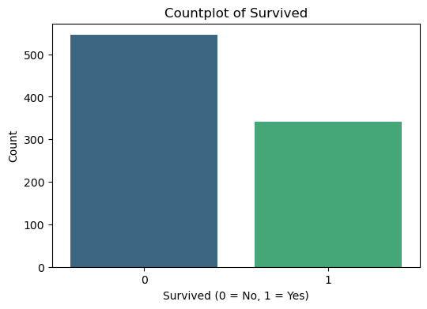

```python
plt.figure(figsize=(6,4))
sns.countplot(data=df, x="Survived", hue="Survived", palette="viridis", legend=False)
plt.title("Countplot of Survived")
plt.xlabel("Survived (0 = No, 1 = Yes)")
plt.ylabel("Count")
plt.show()
```

### Insight: Distribution of Survived

1. تعداد مسافران فوت‌شده (کد 0) برابر با 545 نفر و تعداد نجات‌یافته‌ها (کد 1) برابر با 342 نفر است.
2. نمودار Countplot نیز این توزیع را به‌صورت بصری نمایش می‌دهد؛ ارتفاع ستون مربوط به فوت‌شده‌ها به‌طور قابل‌توجهی بیشتر از ستون نجات‌یافته‌ها است.
3. این نتایج نشان می‌دهد که حدود 61٪ از مسافران جان خود را از دست داده‌اند، در حالی که حدود 39٪ نجات یافته‌اند.
4. این توزیع بیانگر وجود عدم تعادل بین کلاس‌ها است؛ بنابراین در صورت استفاده از این داده‌ها برای مدل‌سازی یادگیری ماشین، بهتر است این موضوع در مراحل آموزش و ارزیابی مدل مورد توجه قرار گیرد.

```python
df["Sex"].value_counts()
```

```
Sex
male      573
female    314
Name: count, dtype: int64
```

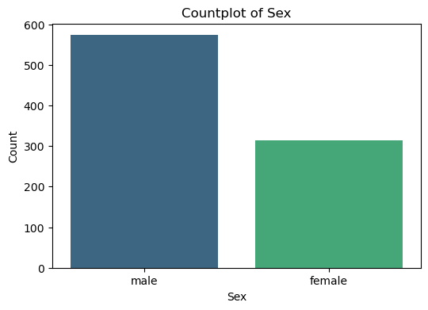

```python
plt.figure(figsize=(6,4))
sns.countplot(data=df, x="Sex", hue="Sex", palette="viridis", legend=False)
plt.title("Countplot of Sex")
plt.xlabel("Sex")
plt.ylabel("Count")
```

### Insight: Distribution of Sex

1. در ستون Sex، تعداد مردان برابر با 573 نفر و تعداد زنان برابر با 314 نفر است؛ این موضوع نشان می‌دهد که حدود 65٪ از مسافران مرد و حدود 35٪ زن بوده‌اند.
2. نمودار Countplot نیز این توزیع را به‌صورت بصری نمایش می‌دهد؛ ارتفاع ستون مربوط به مردان به‌طور قابل‌توجهی بیشتر از ستون زنان است.
3. این توزیع بیانگر عدم توازن در تعداد مردان و زنان در دیتاست است و می‌تواند بر نتایج تحلیل‌های آماری و مدل‌سازی تأثیرگذار باشد.
4. با توجه به پیشینه‌ی حادثه‌ی تایتانیک، انتظار می‌رود جنسیت با احتمال نجات مسافران ارتباط داشته باشد؛ این موضوع را می‌توان با بررسی رابطه‌ی بین Sex و Survived ارزیابی کرد.
5. بنابراین، ستون Sex یکی از ویژگی‌های مهم این دیتاست محسوب می‌شود و بررسی ارتباط آن با متغیر Survived می‌تواند اطلاعات ارزشمندی درباره‌ی الگوی نجات مسافران ارائه دهد.

```python
df["Pclass"].value_counts()
```

```
Pclass
3    487
1    216
2    184
Name: count, dtype: int64
```

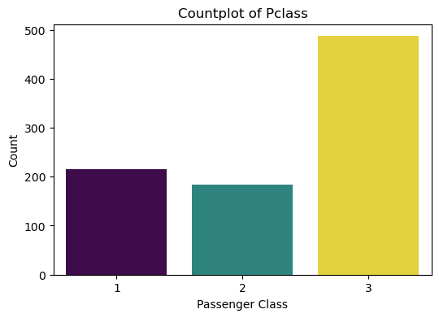

```python
plt.figure(figsize=(6,4))
sns.countplot(data=df, x="Pclass", hue="Pclass", palette="viridis", legend=False)
plt.title("Countplot of Pclass")
plt.xlabel("Passenger Class")
plt.ylabel("Count")
plt.show()
```

### Insight: Distribution of Pclass

1. در ستون Pclass، تعداد مسافران کلاس سوم 487 نفر، کلاس اول 216 نفر و کلاس دوم 184 نفر است؛ این توزیع نشان می‌دهد که بیشترین مسافران این دیتاست در کلاس سوم قرار داشته‌اند.
2. نمودار Countplot نیز همین توزیع را به‌صورت بصری نمایش می‌دهد؛ ارتفاع ستون کلاس سوم به‌طور قابل‌توجهی بیشتر از دو کلاس دیگر است.
3. این توزیع نشان‌دهنده‌ی عدم توازن در تعداد مسافران میان کلاس‌های مختلف سفر است و می‌تواند بر نتایج تحلیل‌های آماری تأثیرگذار باشد.
4. با توجه به پیشینه‌ی حادثه‌ی تایتانیک، انتظار می‌رود کلاس سفر با احتمال نجات مسافران ارتباط داشته باشد؛ این فرضیه را می‌توان با بررسی رابطه‌ی بین Pclass و Survived ارزیابی کرد.
5. بنابراین، ستون Pclass یکی از ویژگی‌های مهم این دیتاست محسوب می‌شود و بررسی ارتباط آن با متغیر Survived می‌تواند اطلاعات ارزشمندی درباره‌ی الگوی نجات مسافران ارائه دهد.

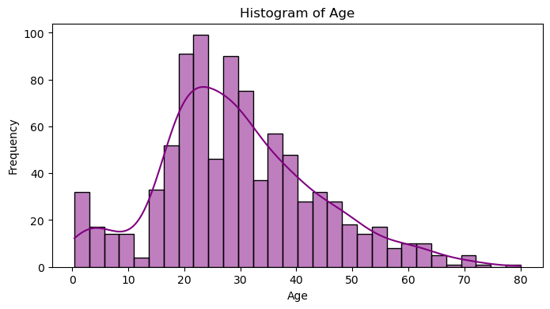

```python
plt.figure(figsize=(8,4))
sns.histplot(data=df, x="Age", bins=30, kde=True, color="purple")
plt.title("Histogram of Age")
plt.xlabel("Age")
plt.ylabel("Frequency")
plt.show()
```

### Insight: Age Distribution (Histogram)

1. توزیع سنی مسافران نشان می‌دهد که بیشترین فراوانی مربوط به افراد جوان، به‌ویژه در بازه‌ی ۲۰ تا ۳۰ سال است؛ این گروه بخش قابل‌توجهی از مسافران را تشکیل می‌دادند.
2. تعداد کودکان (به‌خصوص زیر ۱۰ سال) کمتر است، اما با توجه به سیاست «زنان و کودکان اول»، بررسی ارتباط سن با احتمال نجات در مراحل بعدی اهمیت زیادی دارد.
3. توزیع سن کاملاً نرمال نیست؛ پس از حدود ۵۰ سالگی فراوانی مسافران کاهش می‌یابد و نشان می‌دهد که افراد سالمند حضور کمتری در کشتی داشته‌اند.
4. در انتهای توزیع، چند مقدار بسیار بالا دیده می‌شود که احتمالاً Outlier هستند؛ برای بررسی دقیق‌تر، استفاده از Boxplot مناسب‌تر است.
5. منحنی KDE نشان می‌دهد که توزیع سن دارای یک قله‌ی اصلی (Unimodal) است و دامنه‌ی سنی مسافران گسترده بوده؛ این موضوع تنوع سنی مسافران را تأیید می‌کند.

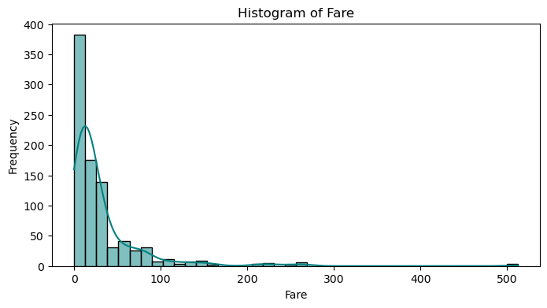

```python
plt.figure(figsize=(8,4))
sns.histplot(data=df, x="Fare", bins=40, kde=True, color="teal")
plt.title("Histogram of Fare")
plt.xlabel("Fare")
plt.ylabel("Frequency")
plt.show()
```

### Insight: Fare Distribution (Histogram)

1. توزیع قیمت بلیت (Fare) نشان می‌دهد که بخش زیادی از مسافران بلیت‌های ارزان‌قیمت داشته‌اند و بیشترین فراوانی در بازه‌های پایین قیمت مشاهده می‌شود.
2. این الگو با تعداد بیشتر مسافران کلاس سوم (Pclass = 3) سازگار است؛ با این حال، برای بررسی دقیق رابطه‌ی بین Fare و Pclass باید تحلیل مشترک این دو متغیر انجام شود.
3. توزیع Fare نرمال نیست و دارای چولگی مثبت (Right-Skewed) است؛ به این معنا که تعداد کمی از مسافران بلیت‌های بسیار گران داشته‌اند و دم توزیع به سمت راست کشیده شده است.
4. در انتهای توزیع، تعداد کمی مقدار با قیمت‌های بسیار بالا مشاهده می‌شود. برای بررسی اینکه آیا این مقادیر Outlier محسوب می‌شوند یا خیر، استفاده از Boxplot مناسب‌تر است.
5. منحنی KDE نشان می‌دهد که توزیع Fare دارای یک قله‌ی اصلی (Unimodal) است و دامنه‌ی قیمت بلیت‌ها نسبتاً گسترده است؛ این موضوع بیانگر تنوع قابل‌توجه قیمت بلیت‌ها در میان مسافران است.

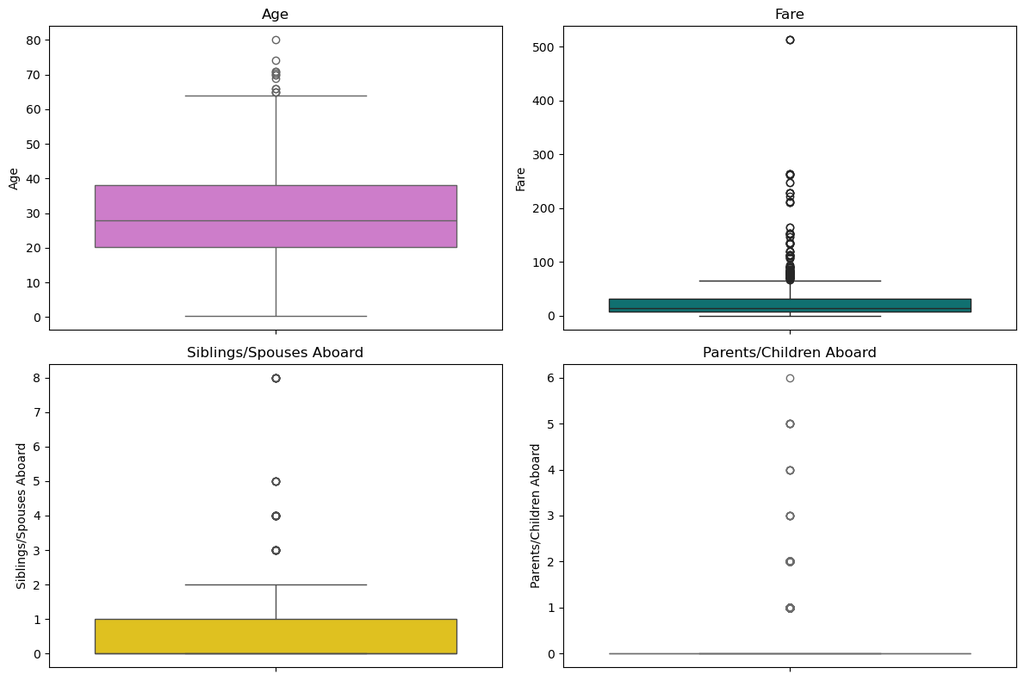

```python
fig = plt.figure(figsize=(12,8))

# Age
ax1 = fig.add_subplot(2, 2, 1)
sns.boxplot(data=df, y="Age", color="orchid", ax=ax1)
ax1.set_title("Age")

# Fare
ax2 = fig.add_subplot(2, 2, 2)
sns.boxplot(data=df, y="Fare", color="teal", ax=ax2)
ax2.set_title("Fare")

# Siblings/Spouses Aboard
ax3 = fig.add_subplot(2, 2, 3)
sns.boxplot(data=df, y="Siblings/Spouses Aboard", color="gold", ax=ax3)
ax3.set_title("Siblings/Spouses Aboard")

# Parents/Children Aboard
ax4 = fig.add_subplot(2, 2, 4)
sns.boxplot(data=df, y="Parents/Children Aboard", color="salmon", ax=ax4)
ax4.set_title("Parents/Children Aboard")

plt.tight_layout()
plt.show()
```

### Insight: Boxplot Analysis of Numerical Features

1. Age  
   نمودار Boxplot مربوط به Age نشان می‌دهد که بیشتر مسافران در بازه‌ی سنی جوان تا میانسال قرار دارند. همچنین چند مقدار در سنین بالاتر به‌صورت Outlier مشاهده می‌شود که بیانگر حضور تعداد کمی از مسافران سالمند در این دیتاست است.
2. Fare  
   نمودار Fare وجود چند Outlier با قیمت‌های بسیار بالا را نشان می‌دهد. همچنین پراکندگی زیاد داده‌ها و فاصله‌ی قابل‌توجه بین میانه و مقادیر بزرگ‌تر، بیانگر چولگی مثبت (Right-Skewed) در توزیع قیمت بلیت‌ها است.
3. Siblings/Spouses Aboard  
   بیشتر داده‌ها در مقدار ۰ متمرکز هستند که نشان می‌دهد اکثر مسافران بدون خواهر، برادر یا همسر سفر کرده‌اند. پراکندگی این متغیر نسبتاً کم است و تنها تعداد محدودی از مسافران با یک یا چند همراه در کشتی حضور داشته‌اند.
4. Parents/Children Aboard  
   در این ستون نیز بیشترین فراوانی مربوط به مقدار ۰ است و تنها تعداد کمی از مسافران همراه با والدین یا فرزندان سفر کرده‌اند. این موضوع نشان می‌دهد که بیشتر مسافران به‌تنهایی یا بدون والدین و فرزندان در سفر بوده‌اند.

### جمع‌بندی

چهار نمودار Boxplot نشان می‌دهند که ویژگی‌های عددی دیتاست Titanic الگوهای پراکندگی متفاوتی دارند:

- Age و Fare دارای پراکندگی بیشتر بوده و چند Outlier قابل‌مشاهده دارند.
- Siblings/Spouses Aboard و Parents/Children Aboard عمدتاً در مقادیر پایین، به‌ویژه مقدار ۰، متمرکز هستند و پراکندگی کمتری دارند.

این ویژگی‌ها می‌توانند در مراحل بعدی تحلیل داده، بررسی Outlier و مدل‌سازی نقش مهمی داشته باشند.

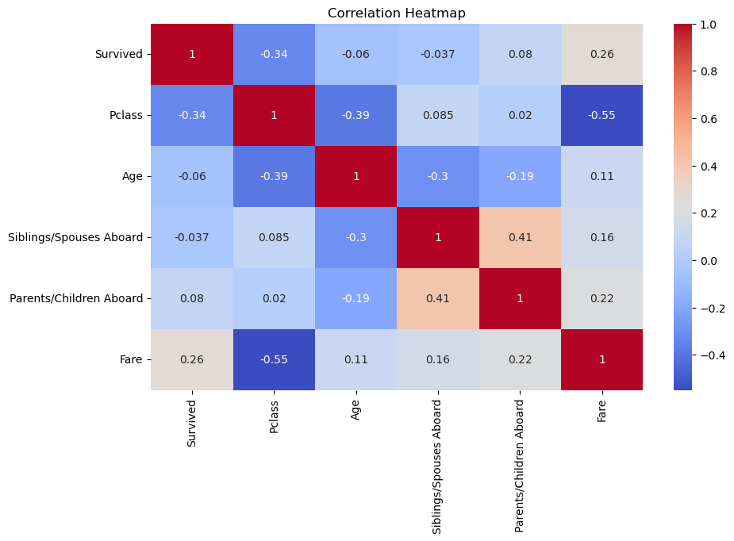

```python
plt.figure(figsize=(10,6))
sns.heatmap(df.corr(numeric_only=True), annot=True, cmap='coolwarm')
plt.title("Correlation Heatmap")
plt.show()
```

### Insight: Correlation Heatmap – Titanic

1. Survived و Pclass  
   همبستگی منفی نسبتاً قوی بین Survived و Pclass (حدود -0.34) نشان می‌دهد که با افزایش مقدار Pclass (از کلاس اول به کلاس سوم)، احتمال نجات کاهش می‌یابد. این متغیر یکی از مهم‌ترین ویژگی‌های عددی برای تحلیل نجات در این دیتاست است.
2. Pclass و Age  
   بین Pclass و Age همبستگی منفی قابل‌توجهی (حدود -0.39) مشاهده می‌شود؛ به این معنا که مسافران کلاس‌های بالاتر به‌طور میانگین سن بیشتری داشته‌اند. این رابطه می‌تواند در تحلیل‌های بعدی مورد بررسی دقیق‌تر قرار گیرد.
3. Age و Survived  
   همبستگی بین Age و Survived بسیار ضعیف و نزدیک به صفر (حدود -0.06) است. این موضوع نشان می‌دهد که در سطح کل دیتاست، رابطه‌ی خطی قابل‌توجهی بین سن و احتمال نجات مشاهده نمی‌شود.
4. Siblings Aboard و سایر متغیرها  
   همبستگی Siblings Aboard با Survived بسیار ضعیف (حدود -0.04) است و نشان می‌دهد رابطه‌ی خطی محسوسی بین این دو متغیر وجود ندارد. همچنین همبستگی منفی آن با Age بیانگر این است که افراد مسن‌تر، به‌طور میانگین، همراهان کمتری داشته‌اند.

### جمع‌بندی

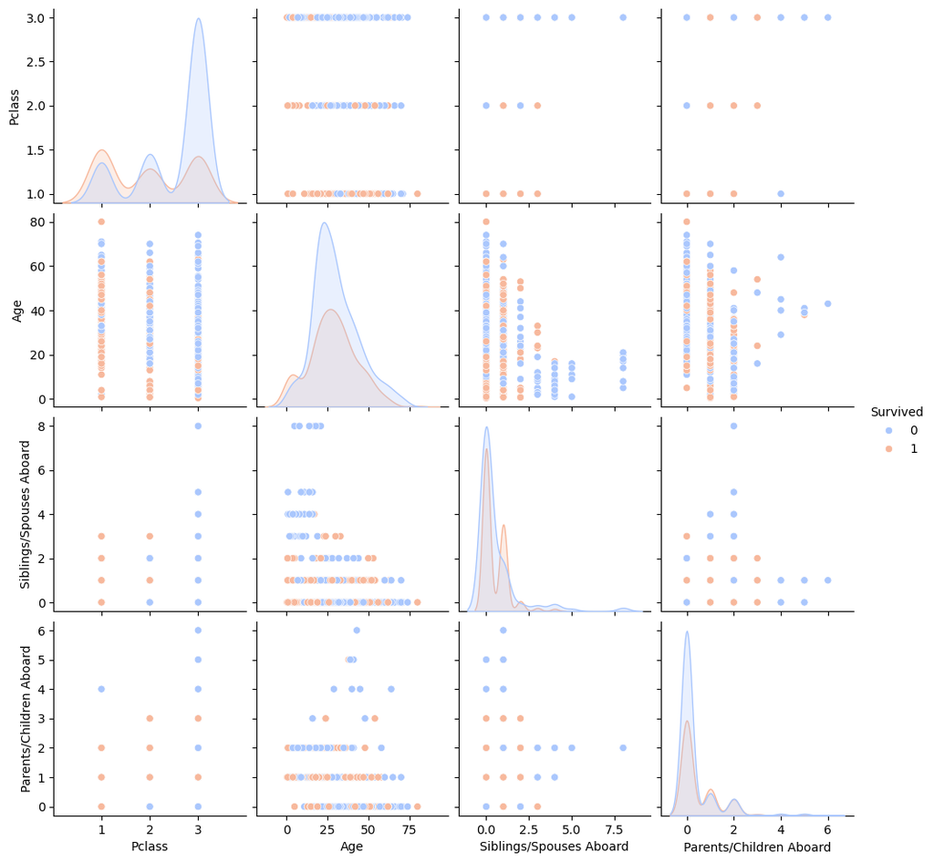

```python
sns.pairplot(df[["Survived", "Pclass", "Age", "Siblings/Spouses Aboard", "Parents/Children Aboard"]],
             hue="Survived",
             diag_kind="kde",
             palette="coolwarm")

plt.show()
```

### Insight: Pairplot – Numerical Features (Titanic)

1. رابطه‌ی Age با سایر متغیرها  
   نمودارهای مربوط به Age نشان می‌دهند که سن مسافران در بازه‌ی گسترده‌ای قرار دارد. نقاط مربوط به افراد نجات‌یافته و نجات‌نیافته در بیشتر بازه‌های سنی مشاهده می‌شوند؛ بنابراین در این بررسی، الگوی خطی واضحی بین Age و Survived دیده نمی‌شود.
2. رابطه‌ی Pclass با Survived  
   در نمودارهای دوبعدی، مشاهده می‌شود که مسافران کلاس سوم (Pclass=3) تراکم بیشتری در میان افراد نجات‌نیافته دارند، در حالی که در کلاس اول (Pclass=1) نسبت نقاط نجات‌یافته بیشتر است. این الگو نشان می‌دهد که بین Pclass و Survived ارتباط قابل‌توجهی وجود دارد.
3. رابطه‌ی Siblings Aboard و Parents/Children Aboard با Survived  
   در نمودارهای مربوط به ویژگی‌های خانوادگی، بیشتر نقاط در مقادیر پایین، به‌ویژه مقدار ۰، متمرکز هستند. این موضوع نشان می‌دهد که بیشتر مسافران همراه خانوادگی ثبت‌شده‌ی کمی داشته‌اند.  
   همچنین الگوی مشخص و واضحی بین تعداد همراهان و وضعیت نجات در نمودارها مشاهده نمی‌شود و نقاط مربوط به نجات‌یافته و نجات‌نیافته در مقادیر مختلف پراکنده هستند.
4. الگوی کلی نقاط در Pairplot  
   در بیشتر نمودارهای دوبعدی، هم‌پوشانی زیادی بین گروه نجات‌یافته و نجات‌نیافته دیده می‌شود؛ با این حال، ویژگی Pclass جدایی بصری بیشتری بین این دو گروه نشان می‌دهد.

### جمع‌بندی

Pairplot نشان می‌دهد که در میان ویژگی‌های عددی، Pclass واضح‌ترین الگوی ارتباطی را با Survived دارد.  
در مقابل، ویژگی‌هایی مانند Age، Siblings Aboard و Parents/Children Aboard در این نمودار رابطه‌ی خطی یا بصری بسیار مشخصی با وضعیت نجات نشان نمی‌دهند.

این نتایج با بررسی‌های قبلی مانند Correlation Heatmap هم‌راستا است و نشان می‌دهد که برای تحلیل دقیق‌تر، بررسی روابط چندمتغیره و مراحل مدل‌سازی می‌تواند مفید باشد.

### جمع‌بندی نهایی

تحلیل اکتشافی داده‌های Titanic نشان می‌دهد که:

- Pclass مهم‌ترین ویژگی عددی از نظر ارتباط با وضعیت نجات است.
- Fare دارای پراکندگی زیاد و چند مقدار پرت قابل‌توجه است و ارزش بررسی بیشتر در تحلیل‌های بعدی را دارد.
- Age و ویژگی‌های خانوادگی الگوهای پراکندگی متفاوتی دارند، اما در این بررسی رابطه‌ی خطی یا بصری قوی با وضعیت نجات نشان نمی‌دهند.
- نتایج این پروژه دید مناسبی از ساختار داده‌ها، توزیع متغیرها و روابط میان ویژگی‌ها ارائه می‌دهد و می‌تواند مبنای مناسبی برای مراحل بعدی تحلیل یا مدل‌سازی باشد.